# 1st_ML

Tarun BT_811390248

2025-02-02

## 1.Conduct basic descriptive statistics, including head, tail, dimensions, summary, structure, mean, mode, median, and check for any missing values.

```r
library(dplyr)
library(readr)
library(psych)
library(modeest)
library(tidyverse)
```

```r
library(ggplot2)
library(tinytex)

data <- read_csv("C:\\Users\\Tarun\\OneDrive\\Desktop\\R program\\Churn.csv")
dim(data) #to find the dimension of data
```

```
## [1] 1000    9
```

```r
summary(data) #to find the summary of data
```

```
##   CallFailures    SubscriptionLength   DataUsage        VoiceMinutes
##  Min.   : 0.000   Min.   : 1.00      Min.   :0.04479   Min.   :   1.913
##  1st Qu.: 5.000   1st Qu.: 6.00      1st Qu.:2.45883   1st Qu.:1392.148
##  Median :10.000   Median :12.00      Median :5.07325   Median :2626.685
##  Mean   : 9.985   Mean   :12.09      Mean   :5.09635   Mean   :2564.964
##  3rd Qu.:16.000   3rd Qu.:18.00      3rd Qu.:7.82260   3rd Qu.:3712.721
##  Max.   :20.000   Max.   :24.00      Max.   :9.99831   Max.   :4998.703
##  CustomerSupportCalls ContractType       MonthlyCharges   RoamingUsage
##  Min.   :0.000        Length:1000        Min.   :20.07   Min.   :0.01345
##  1st Qu.:1.000        Class :character   1st Qu.:37.57   1st Qu.:2.32212
##  Median :2.000        Mode  :character   Median :56.91   Median :4.94221
##  Mean   :2.394                           Mean   :58.42   Mean   :4.95070
##  3rd Qu.:4.000                           3rd Qu.:77.45   3rd Qu.:7.44860
##  Max.   :5.000                           Max.   :99.96   Max.   :9.99680
##      Churn
##  Min.   :0.000
##  1st Qu.:0.000
##  Median :1.000
##  Mean   :0.504
##  3rd Qu.:1.000
##  Max.   :1.000
```

```r
str(data) #to find the structure of data
```

```
## spc_tbl_ [1,000 × 9] (S3: spec_tbl_df/tbl_df/tbl/data.frame)
##  $ CallFailures        : num [1:1000] 16 4 0 9 3 17 16 14 6 3 ...
##  $ SubscriptionLength  : num [1:1000] 11 9 8 9 8 3 8 10 10 2 ...
##  $ DataUsage           : num [1:1000] 4.194 8.409 0.654 8.833 7.246 ...
##  $ VoiceMinutes        : num [1:1000] 4836 1695 4384 2610 2890 ...
##  $ CustomerSupportCalls: num [1:1000] 2 5 3 0 3 1 1 4 3 1 ...
##  $ ContractType        : chr [1:1000] "Monthly" "Monthly" "Monthly" "Monthly" ...
##  $ MonthlyCharges      : num [1:1000] 24.3 82.5 52.9 32.3 58.2 ...
##  $ RoamingUsage        : num [1:1000] 2.6 5.28 3.17 3.03 8.91 ...
##  $ Churn               : num [1:1000] 0 1 0 0 0 1 1 1 0 0 ...
##  - attr(*, "spec")=
##   .. cols(
##   ..   CallFailures = col_double(),
##   ..   SubscriptionLength = col_double(),
##   ..   DataUsage = col_double(),
##   ..   VoiceMinutes = col_double(),
##   ..   CustomerSupportCalls = col_double(),
##   ..   ContractType = col_character(),
##   ..   MonthlyCharges = col_double(),
##   ..   RoamingUsage = col_double(),
##   ..   Churn = col_double()
##   .. )
##  - attr(*, "problems")=<externalptr>
```

```r
describe(data)
```

```
##                      vars    n    mean      sd  median trimmed     mad   min
## CallFailures            1 1000    9.98    6.12   10.00   10.00    7.41  0.00
## SubscriptionLength      2 1000   12.09    6.85   12.00   12.04    8.90  1.00
## DataUsage               3 1000    5.10    2.96    5.07    5.11    3.97  0.04
## VoiceMinutes            4 1000 2564.96 1411.60 2626.69 2577.77 1760.39  1.91
## CustomerSupportCalls    5 1000    2.39    1.72    2.00    2.37    2.97  0.00
## ContractType*           6 1000    1.51    0.50    2.00    1.51    0.00  1.00
## MonthlyCharges          7 1000   58.42   23.07   56.91   58.09   29.64 20.07
## RoamingUsage            8 1000    4.95    2.89    4.94    4.95    3.80  0.01
## Churn                   9 1000    0.50    0.50    1.00    0.50    0.00  0.00
##                          max   range  skew kurtosis    se
## CallFailures           20.00   20.00 -0.01    -1.22  0.19
## SubscriptionLength     24.00   23.00  0.03    -1.15  0.22
## DataUsage              10.00    9.95 -0.02    -1.29  0.09
## VoiceMinutes         4998.70 4996.79 -0.07    -1.14 44.64
## CustomerSupportCalls    5.00    5.00  0.06    -1.29  0.05
## ContractType*           2.00    1.00 -0.03    -2.00  0.02
## MonthlyCharges         99.96   79.89  0.08    -1.19  0.73
## RoamingUsage           10.00    9.98 -0.01    -1.22  0.09
## Churn                   1.00    1.00 -0.02    -2.00  0.02
```

```r
head(data) #to display the head of dataset
```

```
## # A tibble: 6 × 9
##   CallFailures SubscriptionLength DataUsage VoiceMinutes CustomerSupportCalls
##          <dbl>              <dbl>     <dbl>        <dbl>                <dbl>
## 1           16                 11     4.19         4836.                    2
## 2            4                  9     8.41         1695.                    5
## 3            0                  8     0.654        4384.                    3
## 4            9                  9     8.83         2610.                    0
## 5            3                  8     7.25         2890.                    3
## 6           17                  3     0.808        1207.                    1
## # ℹ 4 more variables: ContractType <chr>, MonthlyCharges <dbl>,
## #   RoamingUsage <dbl>, Churn <dbl>
```

```r
tail(data) #to display the tail of dataset
```

```
## # A tibble: 6 × 9
##   CallFailures SubscriptionLength DataUsage VoiceMinutes CustomerSupportCalls
##          <dbl>              <dbl>     <dbl>        <dbl>                <dbl>
## 1            9                 18     6.69         3231.                    4
## 2           14                 13     0.368         221.                    4
## 3           18                 18     3.34         1332.                    4
## 4           11                  5     7.04         4889.                    4
## 5           17                 14     3.95         2522.                    5
## 6           17                 10     0.256        2508.                    4
## # ℹ 4 more variables: ContractType <chr>, MonthlyCharges <dbl>,
## #   RoamingUsage <dbl>, Churn <dbl>
```

```r
numeric_cols <- data %>% select_if(is.numeric) #to extract the numeric value columns

mean_values <- sapply(numeric_cols, mean, na.rm = TRUE) #na.rm=TRUE to ignore the missing values
median_values <- sapply(numeric_cols, median, na.rm = TRUE)
mode_values <- sapply(numeric_cols, function(y) mfv(y, na_rm = TRUE)) #function(y)-Applies a function to each column of the data dataframe. mfv - most frequent value

which.max(table(data$ContractType)) #Finds the most frequent ContractType category in the dataset
```

```
## Monthly
##       2
```

```r
missing_values <- sapply(data, function(y) sum(is.na(y))) #Counts missing (NA) values in each column of the dataset

list(
  Mean = mean_values,
  Median = median_values,
  Mode = mode_values,
  Missing = missing_values
)  # Creates a list storing mean, median, mode, and missing value counts for each column
```

```
## $Mean
##         CallFailures   SubscriptionLength            DataUsage
##             9.985000            12.093000             5.096345
##         VoiceMinutes CustomerSupportCalls       MonthlyCharges
##          2564.964318             2.394000            58.415860
##         RoamingUsage                Churn
##             4.950701             0.504000
##
## $Median
##         CallFailures   SubscriptionLength            DataUsage
##            10.000000            12.000000             5.073246
##         VoiceMinutes CustomerSupportCalls       MonthlyCharges
##          2626.685281             2.000000            56.914490
##         RoamingUsage                Churn
##             4.942205             1.000000
```

[output cut: 656 more lines]

## 2.Write an interpretation of your analysis in part 1(descriptive statistics) in R Markdown report.

The data set used here is 1000 rows and 9 columns, or 1000 observations and 9 variables in R terms. The main goal of this analysis is to investigate how different factors affect customer attrition and extract knowledge using descriptive statistics. Analysis of the data structure revealed that, except for the Contract Type column, which was categorical, all of the variables were numerical. Key statistics for the many variables in the dataset, including the mean, median, and quartiles, are displayed in the summary table. Here, descriptive statistics were employed to learn more about the behavior of the customers. Key statistics, including mean, median, and quartiles for each variable in the dataset, are displayed in the summary table. Descriptive statistics were used to learn more about the behavior of the customers. The is.na command was used to check the dataset for missing values, and the results showed that there were none. The mean value for monthly charges is 58.41, indicating that a fair number of customers are paying higher amounts. With a mean churn value of 0.504, almost half of the customers remain while the other half depart. Additionally, the churn mode was 1, indicating that more consumers were leaving the business than were remaining. Customers experience up to 10 call failures on average, according to the mean number for call failures, which is 10. Some consumers have never experienced a call failure, but others have, and this can lead to churn and customer discontent. Data usage, voice minutes, monthly charges, and roaming usage were found to have no mode when the mode for each variable was examined because each value was distinct.The most popular contract type selected by clients was the monthly type, according to the mode for contract type as well. Additionally, it was noted that while the most frequent number of customer care calls was zero, on average, clients had contacted customer assistance at least twice, indicating persistent or unresolved concerns. There is a concerning discrepancy between the minimum and maximum data usage, which calls for more research.

## 3.Select and compare two or more variables from the dataset, such as DataUsage and Churn. Create a table for the selected variables using the df(dataframe) and select commands.

```r
# Provide summary statistics or visualizations to support your comparison.

selected_data <- data %>% select(DataUsage, Churn) #selecting the variables from the csv file
view(selected_data) #to view the selected data in the table format
print(selected_data) # to print the table details.
```

```
## # A tibble: 1,000 × 2
##    DataUsage Churn
##        <dbl> <dbl>
##  1     4.19      0
##  2     8.41      1
##  3     0.654     0
##  4     8.83      0
##  5     7.25      0
##  6     0.808     1
##  7     1.00      1
##  8     8.14      1
##  9     1.22      0
## 10     7.82      0
## # ℹ 990 more rows
```

```r
cor_value <- cor(selected_data$DataUsage,selected_data$Churn) #Calculates the correlation between Data Usage and Churn to measure their relationship strength and direction.

print(paste("Co-relation value is", cor_value))
```

```
## [1] "Co-relation value is 0.0190527984280555"
```

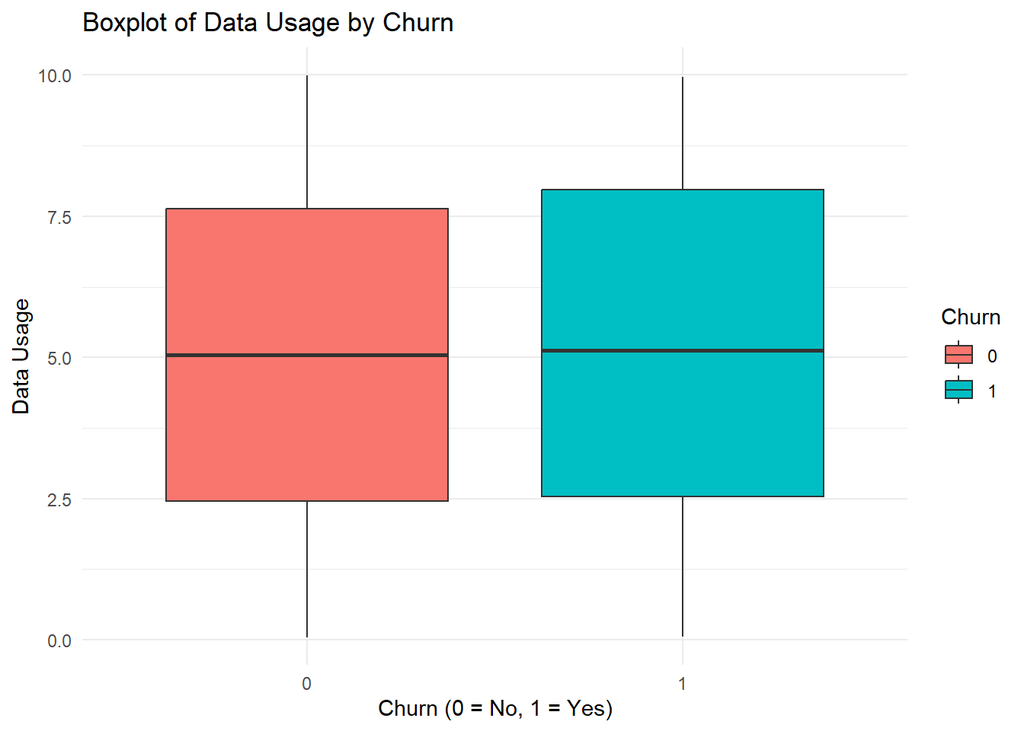

```r
ggplot(selected_data, aes(x = as.factor(Churn), y = DataUsage, fill = as.factor(Churn))) +
  geom_boxplot(outlier.color = "red", outlier.shape = 16, outlier.size = 2) +
  labs(x = "Churn (0 = No, 1 = Yes)", y = "Data Usage",
       fill = "Churn", title = "Boxplot of Data Usage by Churn") +
theme_minimal() # Creates a boxplot to visualize the distribution of Data Usage for each Churn category (0 = No, 1 = Yes), highlighting outliers in red.
```

Conclusion: The analysis suggests no strong relationship between DataUsage and Churn. Both boxplots and correlation values confirm this Other factors like contract type, customer service calls, or pricing might be better indicators of churn

## 4.Transform at least one variable (any transformation such as log(x) and generate a plot using ‘ggplot’ for the transformed variable.

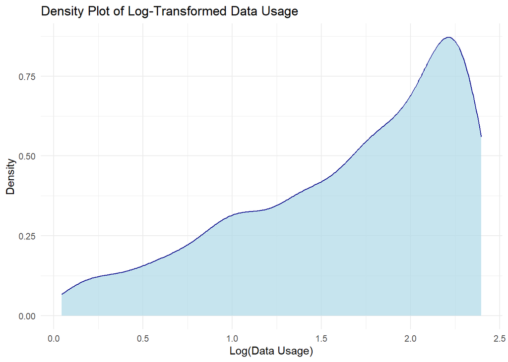

```r
data <- data %>% mutate(LogDataUsage = log(DataUsage + 1)) # Creates a new column 'LogDataUsage' by applying a log transformation to 'DataUsage' to normalize its distribution.


ggplot(data, aes(x = LogDataUsage)) +
  geom_density(fill = "lightblue", color = "darkblue", alpha = 0.7) +
  labs(x = "Log(Data Usage)", y = "Density",
       title = "Density Plot of Log-Transformed Data Usage") +
  theme_minimal() # Generates a density plot to visualize the distribution of log-transformed Data Usage, with a light blue fill and dark blue border.
```